# Whether severe weather events can cause both public health and economic problems

## Synopsis

This project involves exploring the U.S. National Oceanic and Atmospheric Administration’s (NOAA) storm database. The data for this assignment come in the form of a comma-separated-value file compressed via the bzip2 algorithm to reduce its size. This database tracks characteristics of major storms and weather events in the United States, including when and where they occur, as well as estimates of any fatalities, injuries, and property damage.

## Questions

1.Across the United States, which types of events are most harmful with respect to population health?

2.Across the United States, which types of events have the greatest economic consequences?

## Data Processing

Frist reading the data and use **str()** function

```r
storm <- read.csv("storm_data.csv.bz2")
str(storm)
```

```
## 'data.frame':    902297 obs. of  37 variables:
##  $ STATE__   : num  1 1 1 1 1 1 1 1 1 1 ...
##  $ BGN_DATE  : Factor w/ 16335 levels "1/1/1966 0:00:00",..: 6523 6523 4242 11116 2224 2224 2260 383 3980 3980 ...
##  $ BGN_TIME  : Factor w/ 3608 levels "00:00:00 AM",..: 272 287 2705 1683 2584 3186 242 1683 3186 3186 ...
##  $ TIME_ZONE : Factor w/ 22 levels "ADT","AKS","AST",..: 7 7 7 7 7 7 7 7 7 7 ...
##  $ COUNTY    : num  97 3 57 89 43 77 9 123 125 57 ...
##  $ COUNTYNAME: Factor w/ 29601 levels "","5NM E OF MACKINAC BRIDGE TO PRESQUE ISLE LT MI",..: 13513 1873 4598 10592 4372 10094 1973 23873 24418 4598 ...
##  $ STATE     : Factor w/ 72 levels "AK","AL","AM",..: 2 2 2 2 2 2 2 2 2 2 ...
##  $ EVTYPE    : Factor w/ 985 levels "   HIGH SURF ADVISORY",..: 834 834 834 834 834 834 834 834 834 834 ...
##  $ BGN_RANGE : num  0 0 0 0 0 0 0 0 0 0 ...
##  $ BGN_AZI   : Factor w/ 35 levels "","  N"," NW",..: 1 1 1 1 1 1 1 1 1 1 ...
##  $ BGN_LOCATI: Factor w/ 54429 levels "","- 1 N Albion",..: 1 1 1 1 1 1 1 1 1 1 ...
##  $ END_DATE  : Factor w/ 6663 levels "","1/1/1993 0:00:00",..: 1 1 1 1 1 1 1 1 1 1 ...
##  $ END_TIME  : Factor w/ 3647 levels ""," 0900CST",..: 1 1 1 1 1 1 1 1 1 1 ...
##  $ COUNTY_END: num  0 0 0 0 0 0 0 0 0 0 ...
```

[output cut: 23 more lines]

The PROPDMGEXP and CROPDMGEXP variables in the dataset have these unique values:

```r
unique(storm$PROPDMGEXP)
```

```
##  [1] K M   B m + 0 5 6 ? 4 2 3 h 7 H - 1 8
## Levels:  - ? + 0 1 2 3 4 5 6 7 8 B h H K m M
```

```r
unique(storm$CROPDMGEXP)
```

```
## [1]   M K m B ? 0 k 2
## Levels:  ? 0 2 B k K m M
```

Convert the PROPDMGEXP and CROPDMGEXP variables into numerical values

```r
storm$PROPEXP[storm$PROPDMGEXP == "K"] <- 1000
storm$PROPEXP[storm$PROPDMGEXP == "M"] <- 1e+06
storm$PROPEXP[storm$PROPDMGEXP == ""] <- 1
storm$PROPEXP[storm$PROPDMGEXP == "B"] <- 1e+09
storm$PROPEXP[storm$PROPDMGEXP == "m"] <- 1e+06
storm$PROPEXP[storm$PROPDMGEXP == "0"] <- 1
storm$PROPEXP[storm$PROPDMGEXP == "5"] <- 1e+05
storm$PROPEXP[storm$PROPDMGEXP == "6"] <- 1e+06
storm$PROPEXP[storm$PROPDMGEXP == "4"] <- 10000
storm$PROPEXP[storm$PROPDMGEXP == "2"] <- 100
storm$PROPEXP[storm$PROPDMGEXP == "3"] <- 1000
storm$PROPEXP[storm$PROPDMGEXP == "h"] <- 100
storm$PROPEXP[storm$PROPDMGEXP == "7"] <- 1e+07
storm$PROPEXP[storm$PROPDMGEXP == "H"] <- 100
storm$PROPEXP[storm$PROPDMGEXP == "1"] <- 10
storm$PROPEXP[storm$PROPDMGEXP == "8"] <- 1e+08
storm$PROPEXP[storm$PROPDMGEXP == "+"] <- 0
storm$PROPEXP[storm$PROPDMGEXP == "-"] <- 0
storm$PROPEXP[storm$PROPDMGEXP == "?"] <- 0
storm$CROPEXP[storm$CROPDMGEXP == "M"] <- 1e+06
storm$CROPEXP[storm$CROPDMGEXP == "K"] <- 1000
storm$CROPEXP[storm$CROPDMGEXP == "m"] <- 1e+06
storm$CROPEXP[storm$CROPDMGEXP == "B"] <- 1e+09
storm$CROPEXP[storm$CROPDMGEXP == "0"] <- 1
storm$CROPEXP[storm$CROPDMGEXP == "k"] <- 1000
storm$CROPEXP[storm$CROPDMGEXP == "2"] <- 100
storm$CROPEXP[storm$CROPDMGEXP == ""] <- 1
storm$CROPEXP[storm$CROPDMGEXP == "?"] <- 0
```

```r
storm$PROPDMGVAL <- storm$PROPDMG * storm$PROPEXP
storm$CROPDMGVAL <- storm$CROPDMG * storm$CROPEXP
```

Gggregate the data by event

```r
fatal <- aggregate(FATALITIES ~ EVTYPE, data = storm, FUN = sum)
injury <- aggregate(INJURIES ~ EVTYPE, data = storm, FUN = sum)
```

## Results

- Q1: Aross the United States, Which types of events are most harmful with respect to population health?

[figure not shown]

```r
library(ggplot2)
library(gridExtra)
fatal <- fatal[order(-fatal$FATALITIES), ][1:10, ]
injury <- injury[order(-injury$INJURIES), ][1:10, ]
a <- ggplot(data=fatal, aes(EVTYPE ,FATALITIES)) + geom_bar(stat="identity", fill="blue") + ggtitle("Weather Events With The Top 10 Highest Injuries") + ylab("value of injuries") + theme(axis.text.x = element_text(angle = 90, hjust = 1), title =element_text(size=8))
b <- ggplot(data=injury, aes(EVTYPE ,injury$INJURIES)) + geom_bar(stat="identity", fill="green") + ggtitle("Weather Events With The Top 10 Highest Fatalities") + ylab("value of fatalities") + theme(axis.text.x = element_text(angle = 90, hjust = 1), title =element_text(size=8))
grid.arrange(a, b ,ncol=2, main="Storm Events and Population Health" )
```

So, The most harmful weather event to population health is **Tornado**.

- Q2: Across the United States, which types of events have the greatest economic consequences?

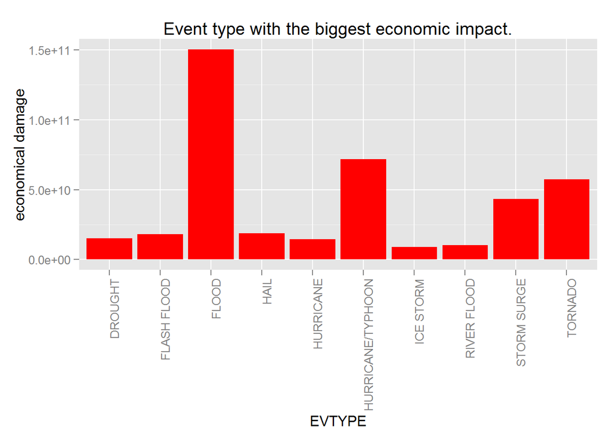

```r
storm$damage <- storm$PROPDMGVAL + storm$CROPDMGVAL
totaldamage <- aggregate(damage ~ EVTYPE, data = storm, FUN = sum)
totaldamage <- totaldamage[order(-totaldamage$damage), ][1:10, ]
ggplot(data=totaldamage, aes(EVTYPE ,damage)) + geom_bar(stat="identity", fill="red") + ggtitle("Event type with the biggest economic impact.") + ylab("economical damage") + theme(axis.text.x = element_text(angle = 90, hjust = 1))
```

So, The biggest impact event type to the economic impact is **FLOOD**.